# INTRODUCTION TO GGPLOT2: AESTHETICS

### 2.2 Color, fill, shape and size

Load the **mtcars** dataset again:

```r
data(mtcars)
str(mtcars)
```

```
## 'data.frame':    32 obs. of  11 variables:
##  $ mpg : num  21 21 22.8 21.4 18.7 18.1 14.3 24.4 22.8 19.2 ...
##  $ cyl : num  6 6 4 6 8 6 8 4 4 6 ...
##  $ disp: num  160 160 108 258 360 ...
##  $ hp  : num  110 110 93 110 175 105 245 62 95 123 ...
##  $ drat: num  3.9 3.9 3.85 3.08 3.15 2.76 3.21 3.69 3.92 3.92 ...
##  $ wt  : num  2.62 2.88 2.32 3.21 3.44 ...
##  $ qsec: num  16.5 17 18.6 19.4 17 ...
##  $ vs  : num  0 0 1 1 0 1 0 1 1 1 ...
##  $ am  : num  1 1 1 0 0 0 0 0 0 0 ...
##  $ gear: num  4 4 4 3 3 3 3 4 4 4 ...
##  $ carb: num  4 4 1 1 2 1 4 2 2 4 ...
```

`cyl` shows the number of cylinders of a car and `am` gives the information about the transmission (0 = automatic, 1 = manual). Both of theses columns are categorical data type but shown in the dataset as numeric variables. Transform the two columns into factors:

```r
mtcars <- mtcars %>%
  mutate(fcyl = as.factor(cyl),
         fam = as.factor(am))
```

Map `mpg` (miles per gallon) onto the `x` aesthetic, and `fcyl` onto the `y`:

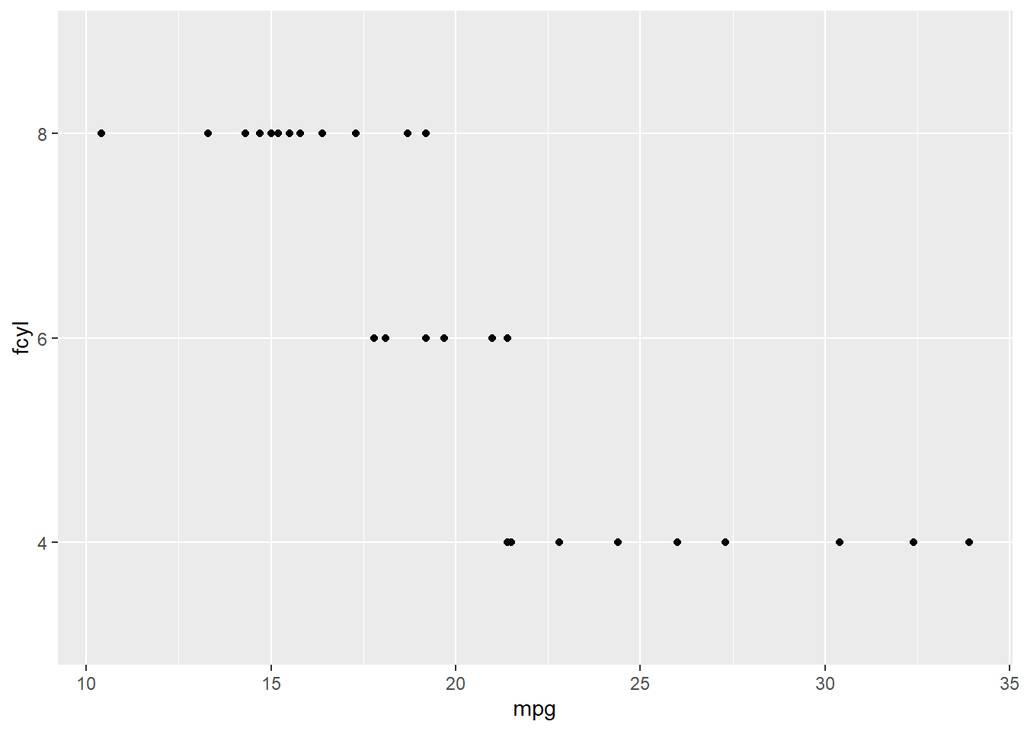

```r
ggplot(mtcars, aes(mpg, fcyl)) +
  geom_point()
```

Swap the mappings: `fcyl` onto the `x` aesthetic, and `mpg` onto the `y`:

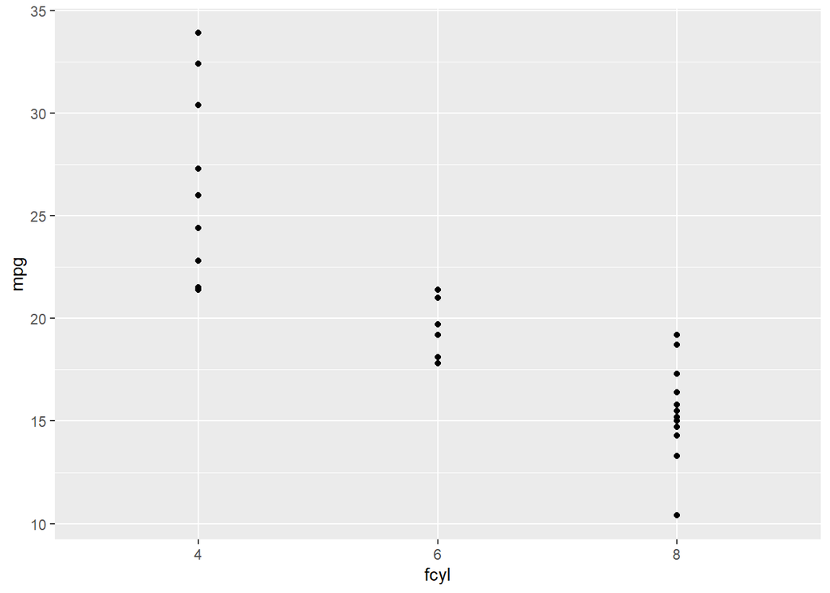

```r
ggplot(mtcars, aes(fcyl, mpg)) +
  geom_point()
```

Map `wt` (weight) onto `x`, `mpg` onto `y`, and `fcyl` onto `color`:

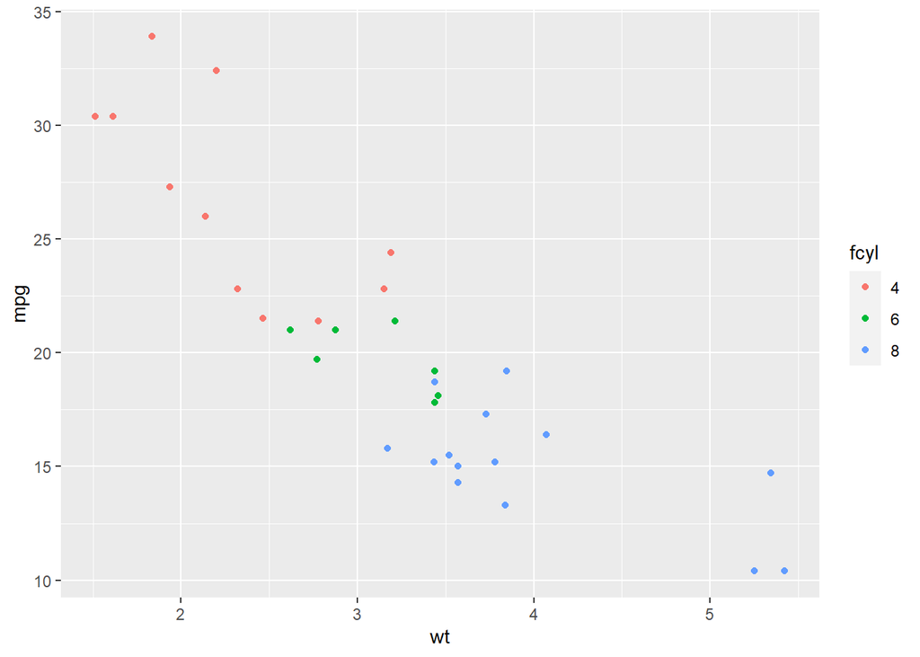

```r
ggplot(mtcars, aes(wt, mpg,
                   color = fcyl)) +
  geom_point()
```

Modify the point layer by changing the shape and increasing the size:

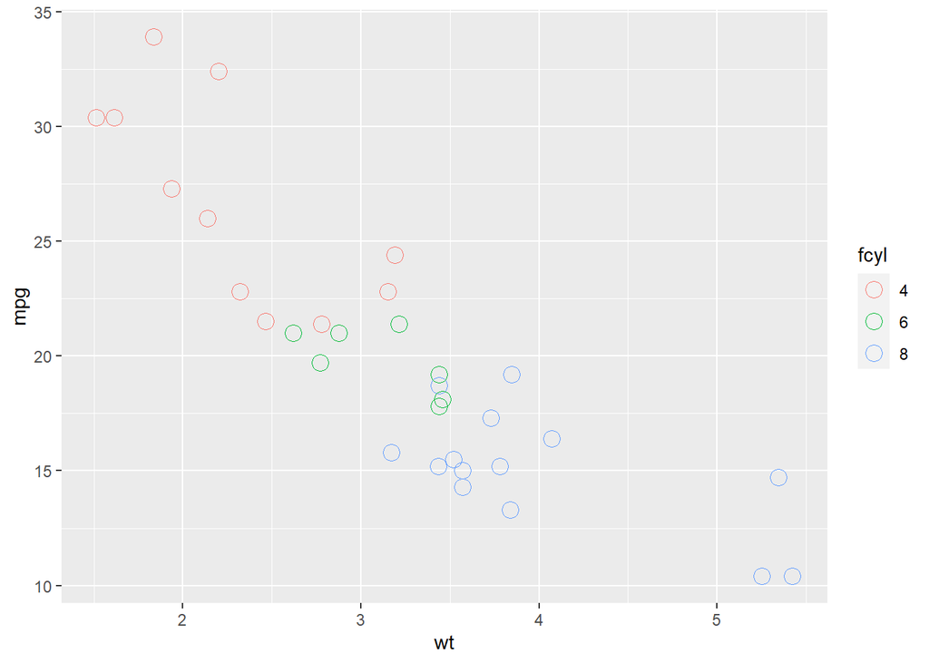

```r
ggplot(mtcars, aes(wt, mpg,
                   color = fcyl)) +
  geom_point(shape = 1, size = 4)
```

Typically, the color aesthetic changes the outline of a geom and the fill aesthetic changes the inside. `geom_point()` is an exception: you use color (not fill) for the point color. However, some shapes have special behavior. The default `geom_point()` uses `shape = 19`: a solid circle. An alternative is `shape = 21`: a circle that allow you to use both fill for the inside and color for the outline. This is lets you to map two aesthetics to each point.

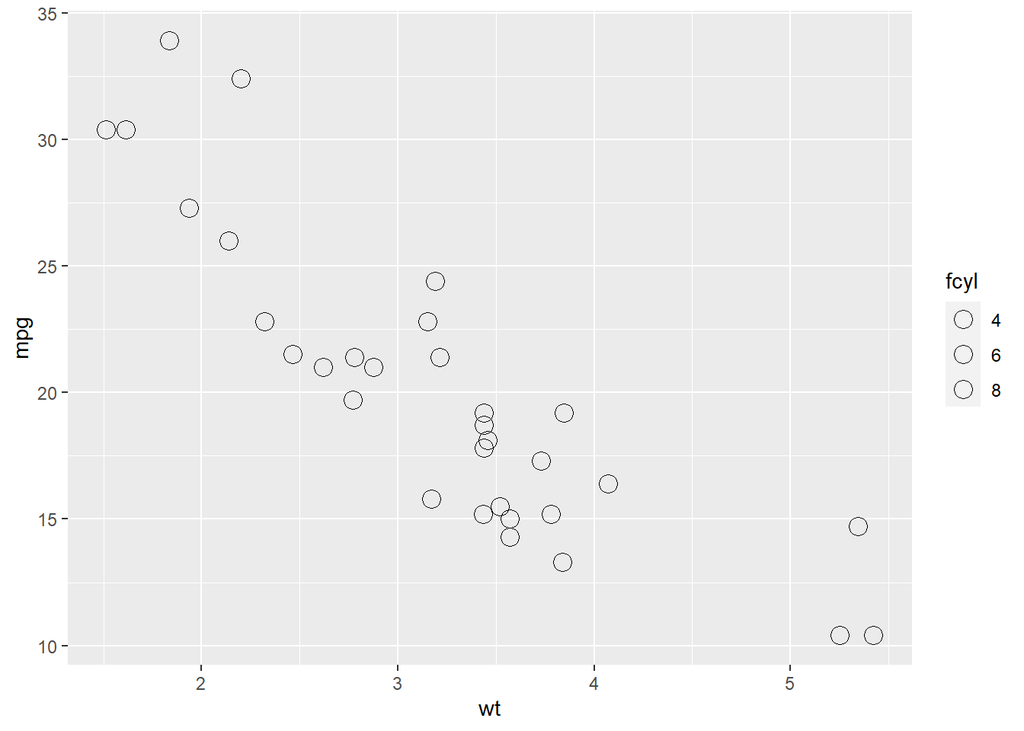

```r
ggplot(mtcars, aes(wt, mpg,
                   fill = fcyl)) +
  geom_point(shape = 1, size = 4)
```

Mapping a categorical variable onto `fill` does not change the colors, although a legend is generated! This is because the default shape for points only has a color attribute and not a fill attribute! Use `fill` when you have another shape (such as a bar), or when using a point that does have a fill and a color attribute, such as `shape = 21`, which is a circle with an outline.

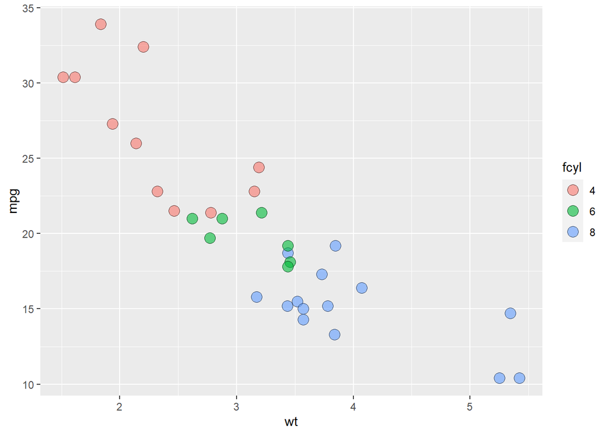

```r
ggplot(mtcars, aes(wt, mpg,
                   fill = fcyl)) +
  geom_point(shape = 21, size = 4, alpha = 0.6)
```

Any time you use a solid color, make sure to use alpha blending to account for over plotting.

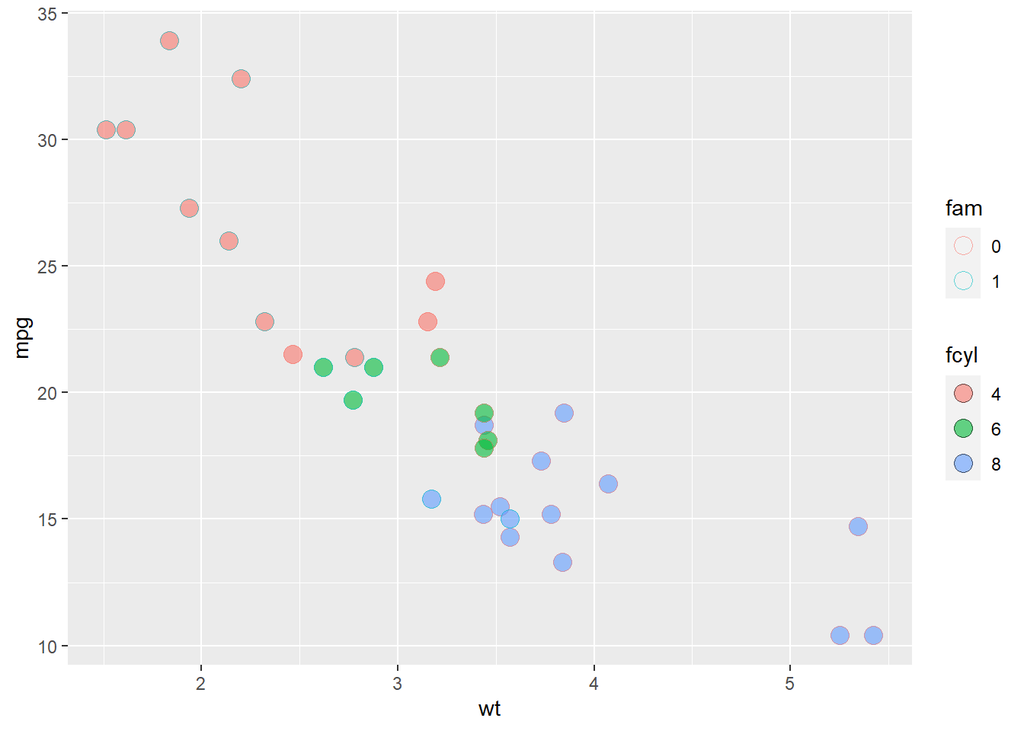

```r
ggplot(mtcars, aes(wt, mpg,
                   fill = fcyl,
                   color = fam)) +
  geom_point(shape = 21, size = 4, alpha = 0.6)
```

Comparing aesthetics: first create a base layer that maps `mpg` to `y` and `wt` to `x`:

```r
plt_mpg_vs_wt <- ggplot(mtcars, aes(wt, mpg))
```

Add a point layer, mapping the categorical number of cylinders, `fcyl`, onto `size`:

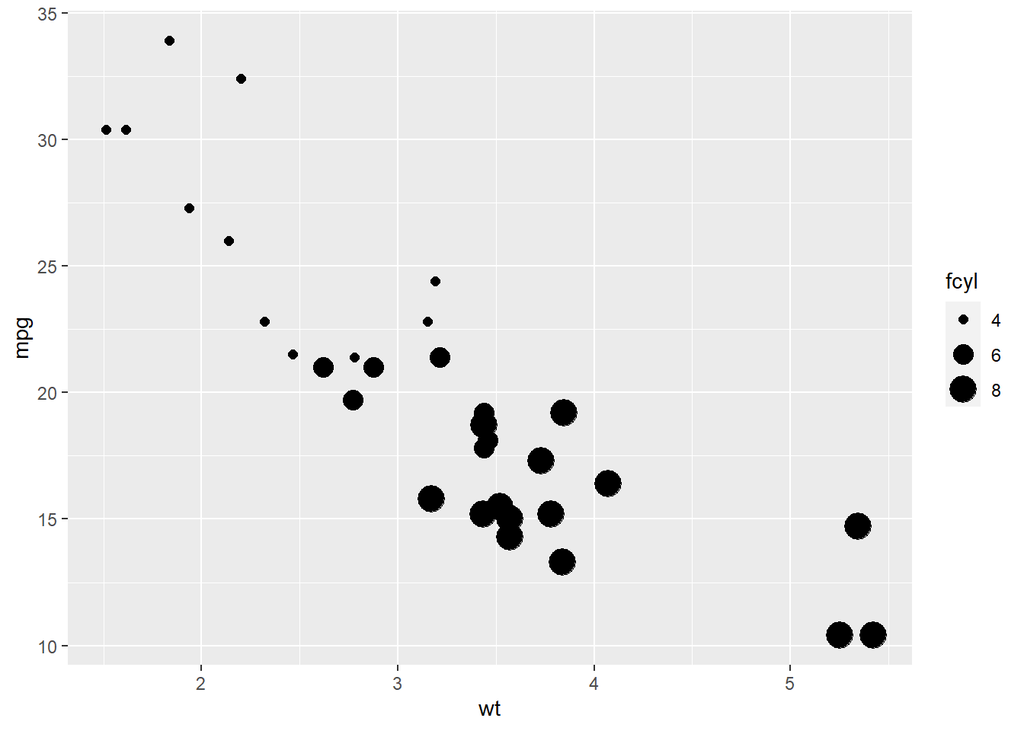

```r
plt_mpg_vs_wt + geom_point(aes(size = fcyl))
```

Change the mapping of `fcyl` to `alpha`:

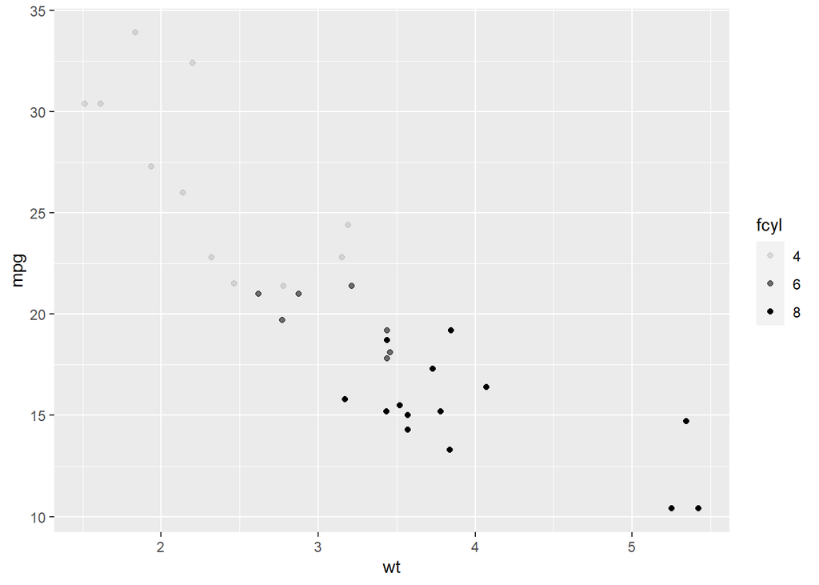

```r
plt_mpg_vs_wt + geom_point(aes(alpha = fcyl))
```

Change the mapping of `fcyl` to `shape`:

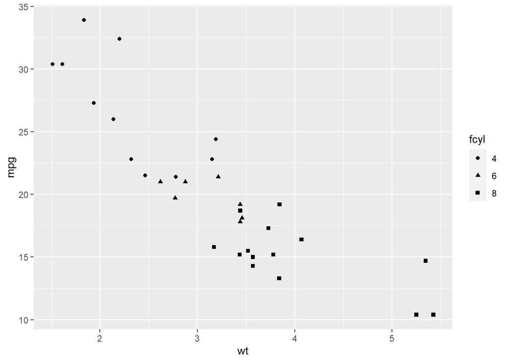

```r
plt_mpg_vs_wt + geom_point(aes(shape = fcyl))
```

Swap the geom layer: change points to text.

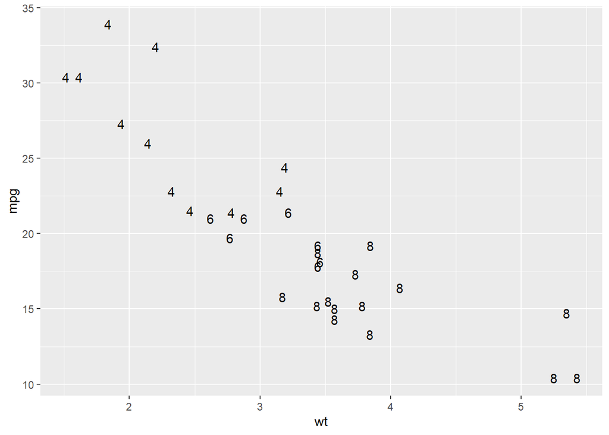

```r
plt_mpg_vs_wt + geom_text(aes(label = fcyl))
```

Many of the aesthetics can accept either continuous or categorical variables, but some are restricted to categorical data, like `label` and `shape`.

### 2.3 Attributes

One of the most confusing parts of **ggplot2** is that all the visible aesthetics also exist as attributes.

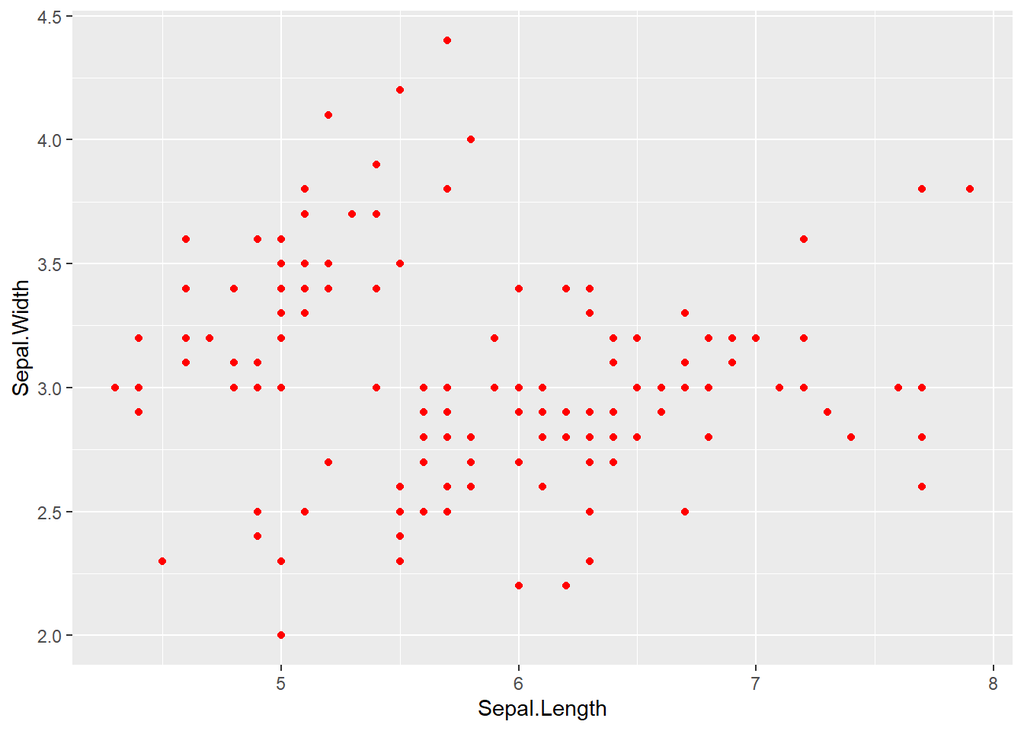

```r
ggplot(iris, aes(Sepal.Length, Sepal.Width)) +
  geom_point(color = "red")
```

Attributes are always called in the `geom` layer, like `color`, `size` and `shape`.

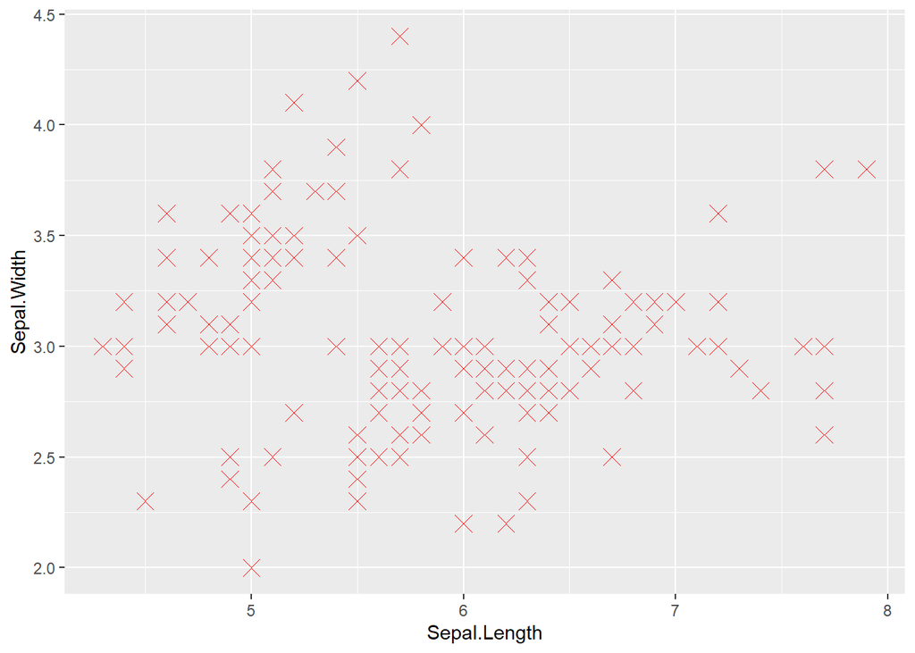

```r
ggplot(iris, aes(Sepal.Length, Sepal.Width)) +
  geom_point(color = "red", size = 4, shape = 4)
```

The distinction between aesthetics and attributes is subtle but important.

All the aesthetics can be used as attributes. For example, add attributes to the `geom` layer for the plot of **mtcars**:

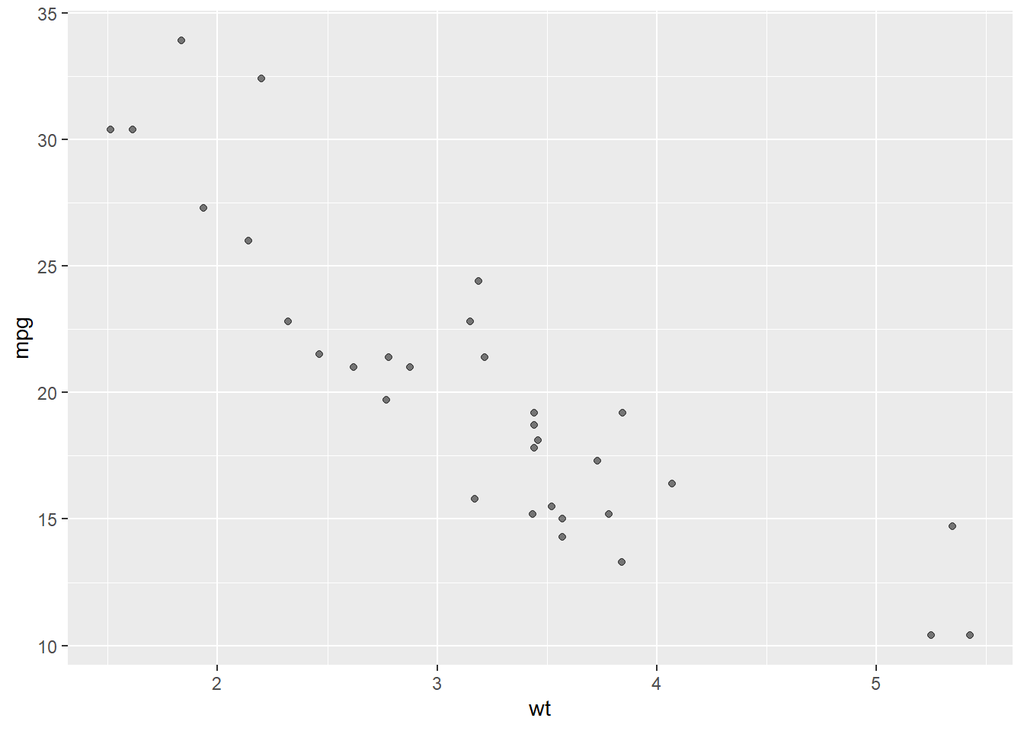

```r
plt_mpg_vs_wt + geom_point(alpha = 0.5)
```

Add a text layer with label `rownames` and color red:

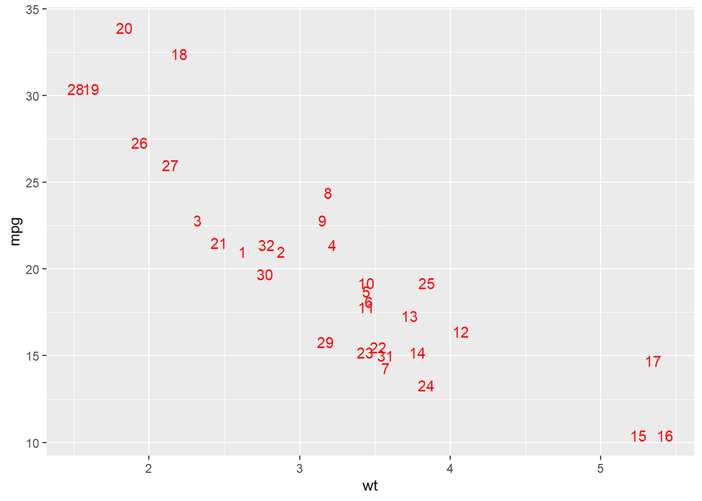

```r
plt_mpg_vs_wt + geom_text(label = rownames(mtcars),
                          color = "red")
```

Colors in R can be specified by using hex codes.

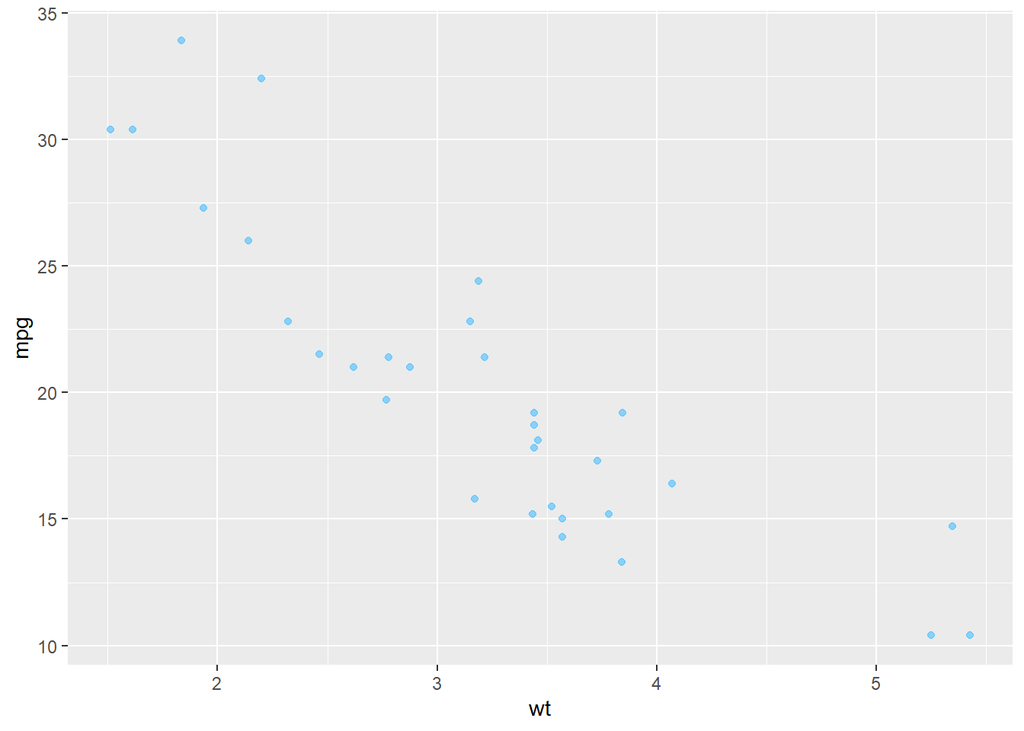

```r
my_blue <- "#4ABEFF"
plt_mpg_vs_wt +
  geom_point(color = my_blue,
             alpha = 0.6)
```

Change the color both in aesthetics mapping and attributes:

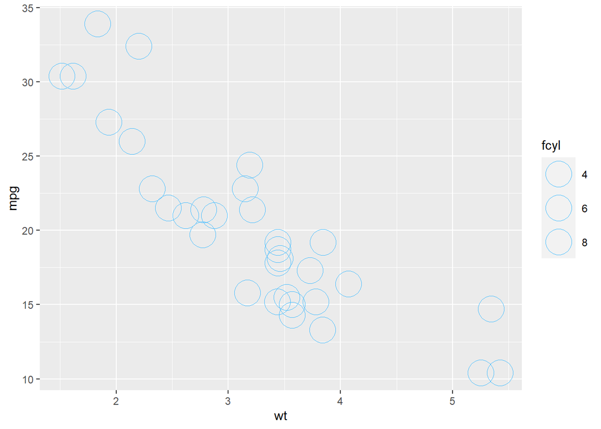

```r
ggplot(mtcars, aes(wt, mpg,
                   fill = fcyl)) +
  geom_point(color = my_blue,
             size = 10,
             shape = 1)
```

Explore more features of the cars in the **mtcars** dataset:

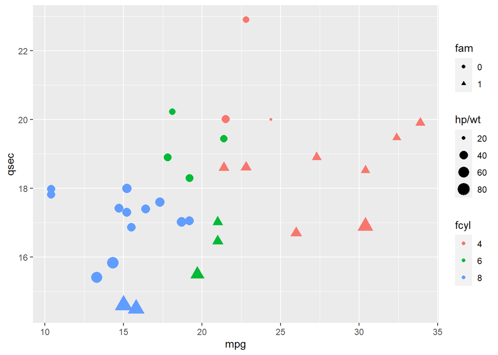

```r
ggplot(mtcars, aes(mpg, qsec,         # qsec: 1/4 mile time
                   color = fcyl,
                   shape = fam,
                   size = hp/wt)) +   # hp: Gross horsepower.
  geom_point()
```

### 2.4 Modifying aesthetics

Adding more aesthetic layers to the plot will increase the complexity and decrease the readability.

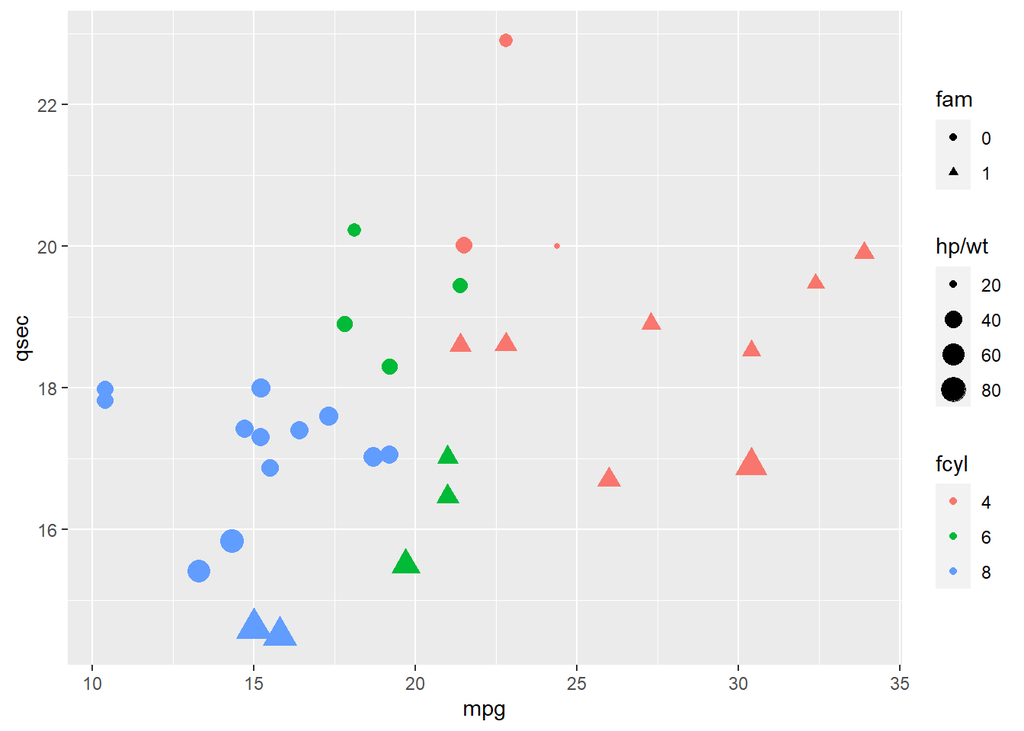

```r
ggplot(mtcars, aes(mpg, qsec, color = fcyl,
                   shape = fam,
                   size = hp/wt)) +
  geom_point()
```

A common adjustment is *position*. *Position* specifies how **ggplot2** will adjust for overlapping bars or points on a single layer.

The most straightforward position is `identity`. The value in the data frame is exactly where the value is positioned in the plot. We could specify the argument in `geom_point`, but there is no need , because it is the default position for a scatter plot.

```r
ggplot(iris, aes(Sepal.Length, Sepal.Width,
                 color = Species)) +
  geom_point(position = "identity")
```

[output not shown]

This basically means do not do anything, just put the information where the data says to put the information.

There is an issue with the precision of this data set. The sepals were measured to the nearest millimeter. Although there’re only 150 points, it’ll be too much overplotting to distinguish them. Add some random noise on both x and y axes to see regions of high density - *jittering*.

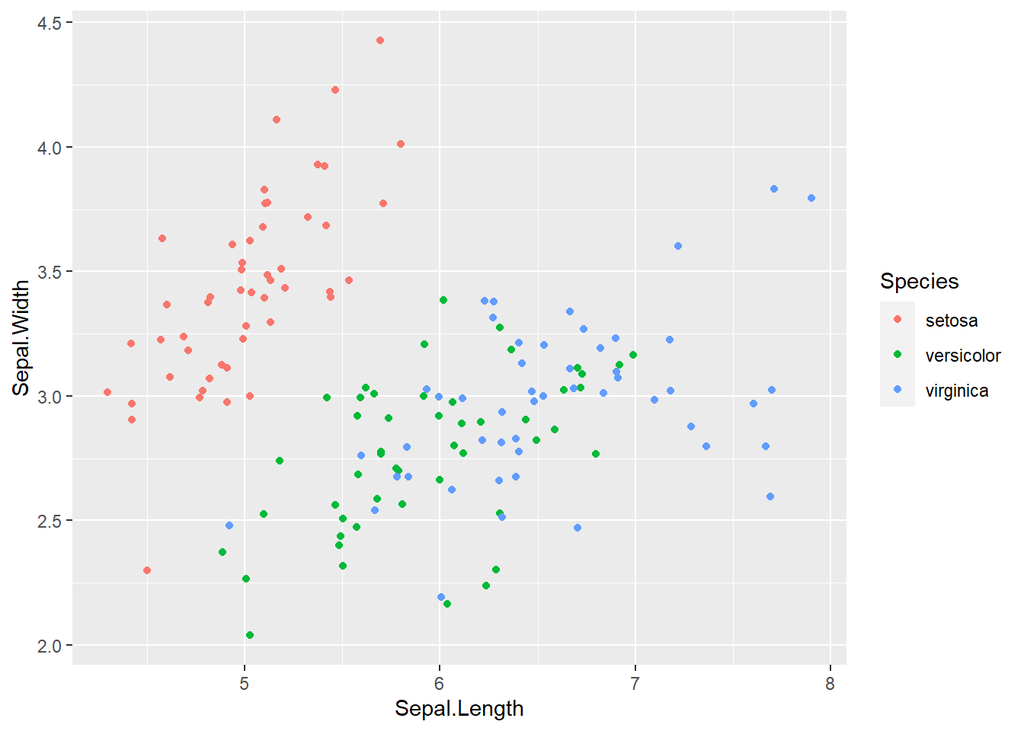

```r
ggplot(iris, aes(Sepal.Length, Sepal.Width,
                 color = Species)) +
  geom_point(position = "jitter")
```

`jitter` can be used as an argument, but each position type can also be accessed as a function, for example, `position_jitter` can be defined as a function before plotting.

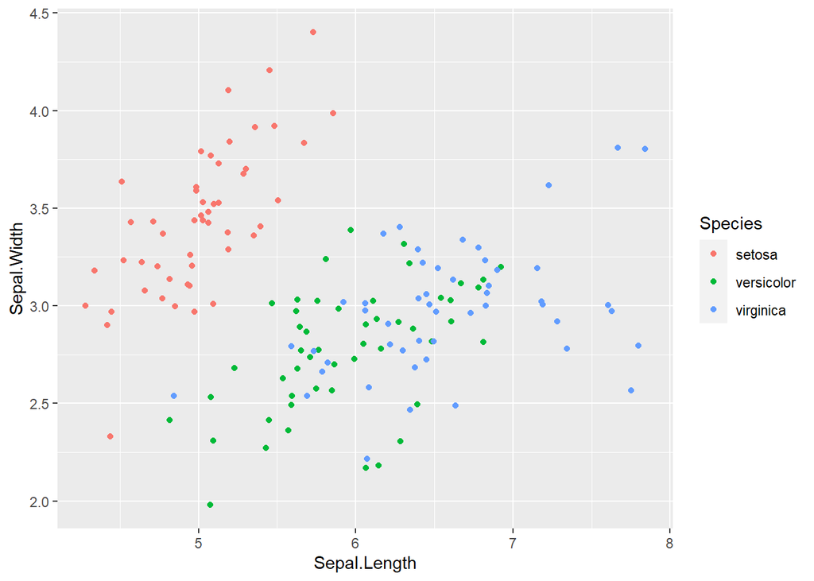

```r
posn_j <- position_jitter(0.1)
ggplot(iris, aes(Sepal.Length, Sepal.Width,
                 color = Species)) +
  geom_point(position = posn_j)
```

This has advantages, as we can set the specific arguments for the position and the position function allows to use the parameter throughout the plotting, which maintains the consistency across plots and layers.

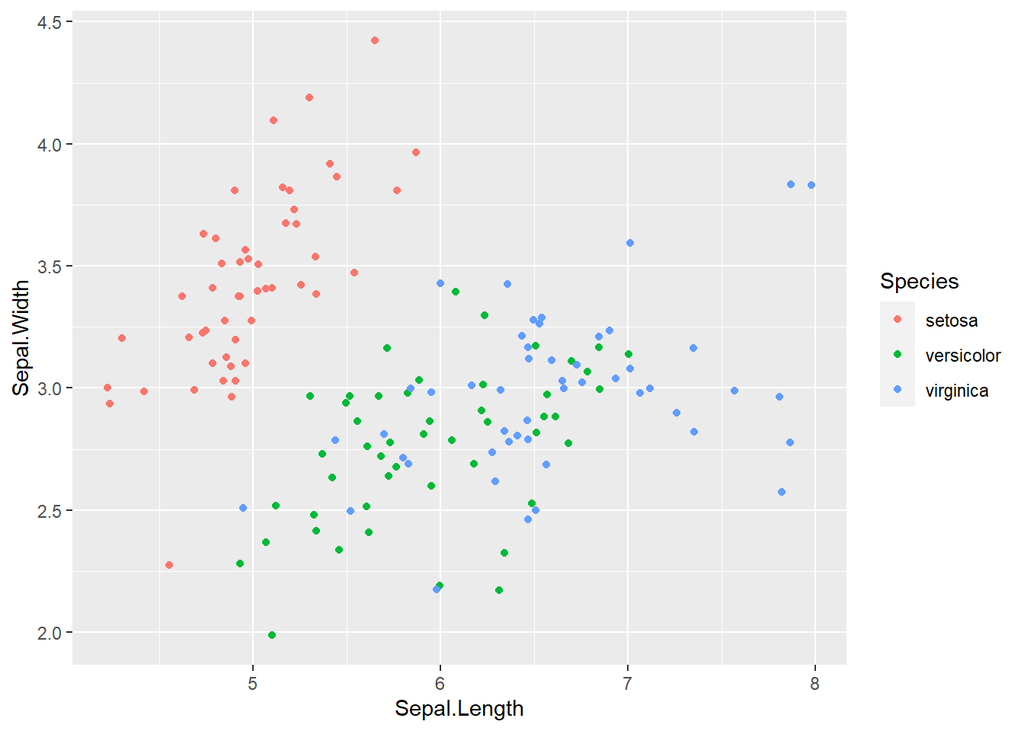

```r
posn_j <- position_jitter(0.2, seed = 136) # "seed" defines how much random noise should be added.
# Run the plot again:
ggplot(iris, aes(Sepal.Length, Sepal.Width,
                 color = Species)) +
  geom_point(position = posn_j)
```

### 2.5 Scale functions

Each of the aesthetics is a scale which is mapped onto the data. We can access all the scale functions with the syntax `scale_*_*`. All the aesthetics have an associated scale functions.

- `scale_x_*()`
- `scale_y_*()`
- `scale_color_*()`
- `scale_fill_*()`
- `scale_shape_*()`
- `scale_linetype_*()`
- `scale_size_*()`

The second part of the scale function syntax defines which scale we want to modify, and the third must matches the of data we are using.

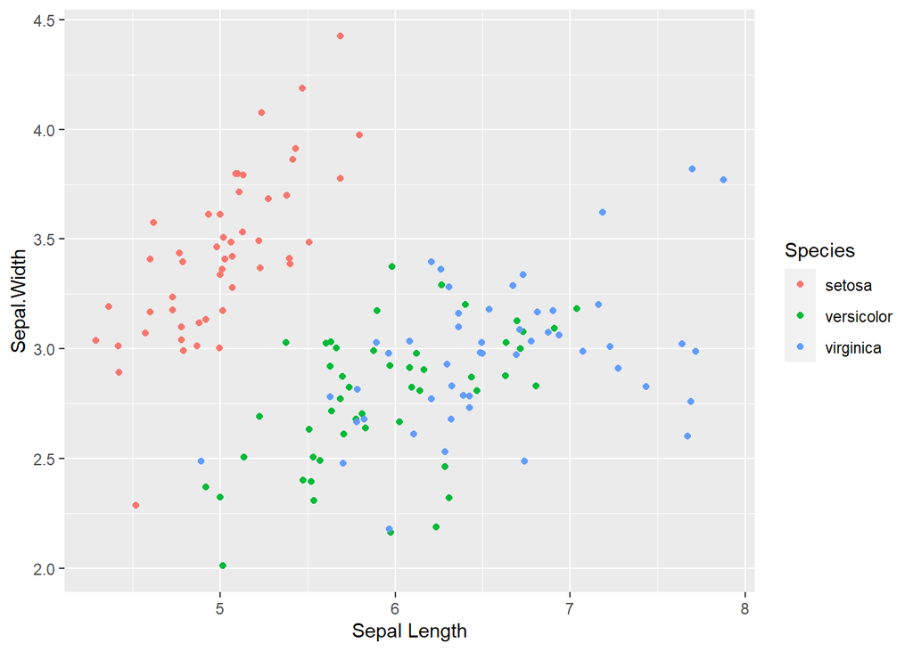

```r
ggplot(iris, aes(Sepal.Length, Sepal.Width,
                 color = Species)) +
  geom_point(position = "jitter") +
  scale_x_continuous("Sepal Length") +
  scale_color_discrete("Species") # "discrete": categorical data.
```

Here means that we have to choose the axis dependent on the data we have, like the continuous x aesthetic and the categorical color aesthetic.

There are many arguments for the scale functions. The first argument is always the name of the scale, following by mostly `limits`, `breaks`, `expand` and `labels`.

- `limits`: describes the scale’s range

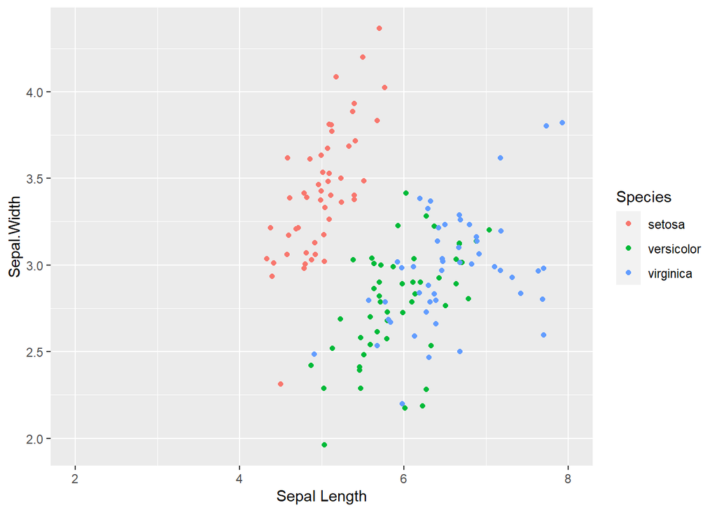

```r
ggplot(iris, aes(x = Sepal.Length, y = Sepal.Width,
                 color = Species)) +
  geom_point(position = "jitter") +
  scale_x_continuous("Sepal Length",
                     limits = c(2, 8)) +
  scale_color_discrete("Species")
```

- `break`: controls the tick mark positions.

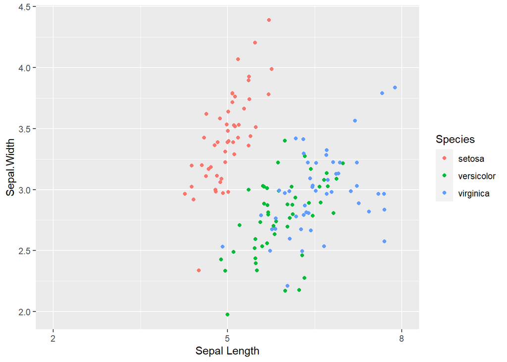

```r
ggplot(iris, aes(Sepal.Length, Sepal.Width,
                 color = Species)) +
  geom_point(position = "jitter") +
  scale_x_continuous("Sepal Length", limits = c(2, 8),
                     breaks = seq(2, 8, 3)) +
  scale_color_discrete("Species")
```

- `expand`: a numeric vector of length 2, giving a multiplicative and additive constant used to expand the scales so that there is a small gap between the data and the axes.

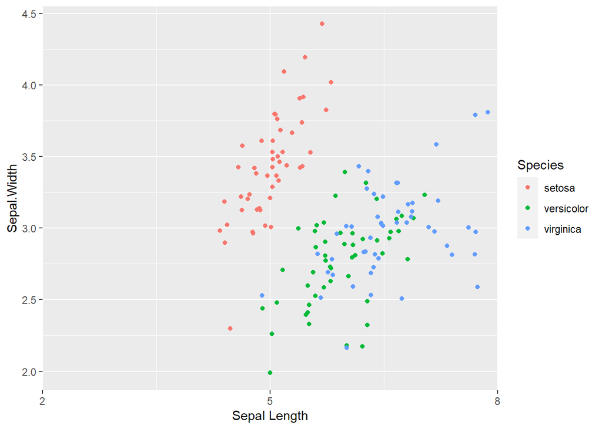

```r
ggplot(iris, aes(Sepal.Length, Sepal.Width,
                 color = Species)) +
  geom_point(position = "jitter") +
  scale_x_continuous("Sepal Length", limits = c(2, 8),
                     breaks = seq(2, 8, 3),
                     expand = c(0, 0)) +
  scale_color_discrete("Species")
```

- `labels`: adjust catgorical names.

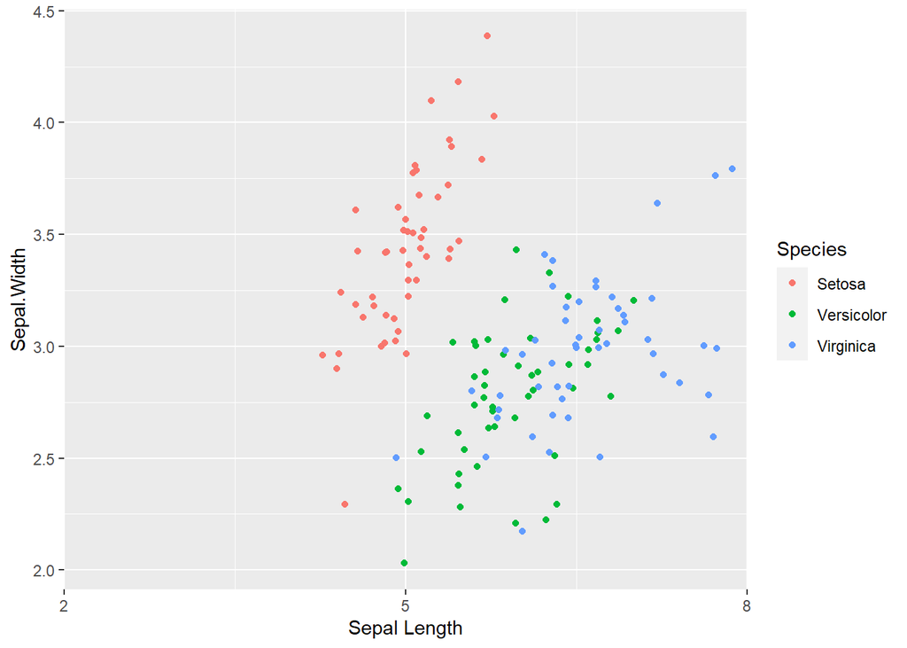

```r
ggplot(iris, aes(Sepal.Length, Sepal.Width,
                 color = Species)) +
  geom_point(position = "jitter") +
  scale_x_continuous("Sepal Length", limits = c(2, 8),
                     breaks = seq(2, 8, 3),
                     expand = c(0, 0)) +
  scale_color_discrete("Species",
                       labels = c("Setosa", "Versicolor", "Virginica"))
```

Note that if we just want to change the axis labels quickly, we can use `labs()`.

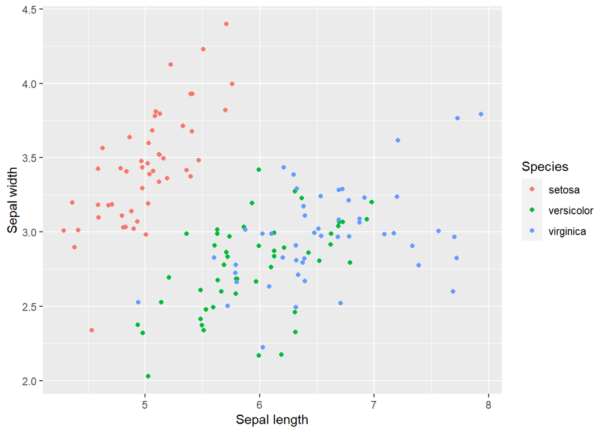

```r
ggplot(iris, aes(Sepal.Length, Sepal.Width,
                 color = Species)) +
  geom_point(position = "jitter") +
  labs(x = "Sepal length", y = "Sepal width")
```

Modify some aesthetics to make a bar plot of the number of cylinders for cars with different types of transmission in the **mtcars** dataset.

```r
mtcars_gg <- ggplot(mtcars, aes(fcyl, fill = fam)) +
  geom_bar()
```

Set the axis labels:

```r
mtcars_gg <- mtcars_gg +
  labs(x = "Number of Cyclinders", y = "Count")
```

Implement a custom fill color scale using `scale_fill_manual()`:

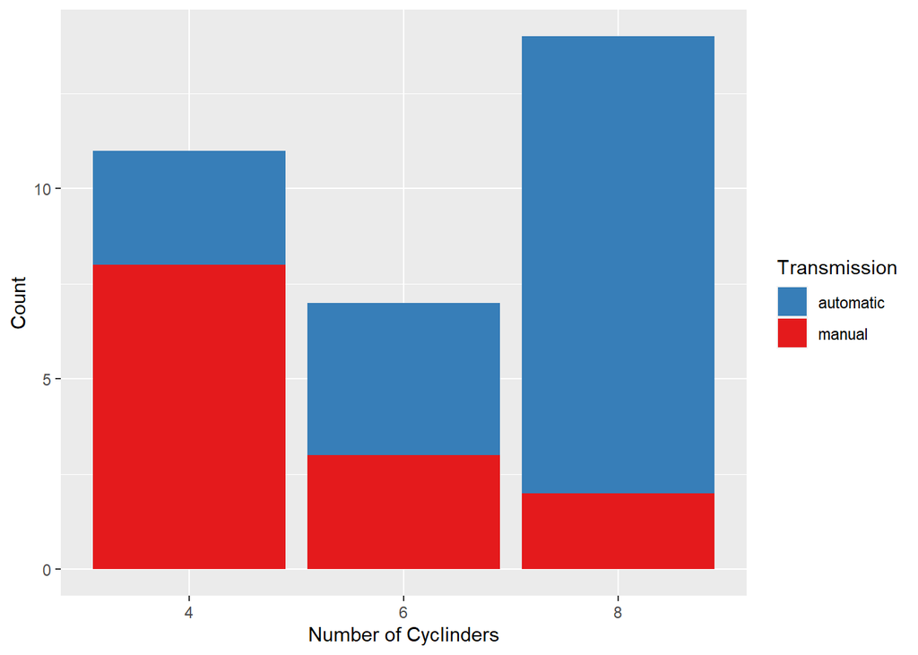

```r
palette <- c("#377EB8", "#E41A1C")
mtcars_gg + scale_fill_manual("Transmission", values = palette,
                              labels = c("automatic", "manual"))
```

Modify the position so that the bars for transmission are displayed side by side:

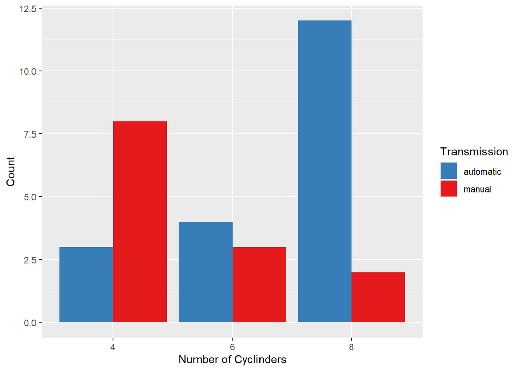

```r
ggplot(mtcars, aes(fcyl, fill = fam)) +
  geom_bar(position = "dodge") +
  labs(x = "Number of Cyclinders", y = "Count") +
  scale_fill_manual("Transmission", values = palette,
                    labels = c("automatic", "manual"))
```

Although you can make univariate plots (such as histograms), a `y-axis` will always be provided. You can make univariate plots in **ggplot2**, but you will need to add a fake y axis by mapping y to zero.

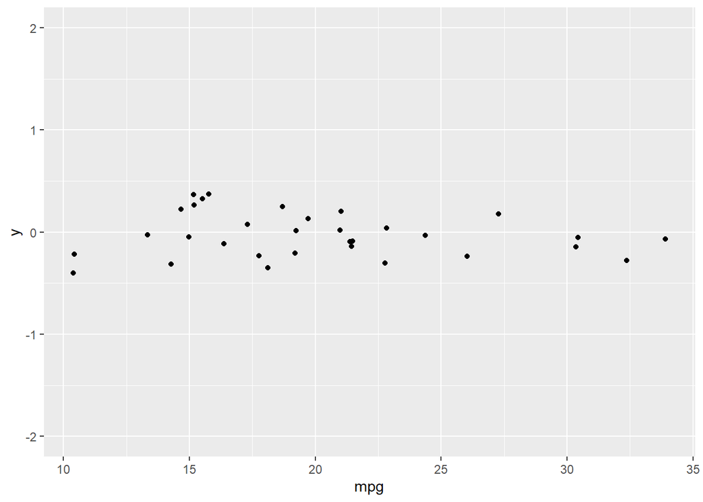

```r
ggplot(mtcars, aes(mpg, 0)) +
  geom_point(position = "jitter") +
  ylim(-2, 2)
```

When using setting y-axis limits, you can specify the limits as separate arguments, or as a single numeric , like `ylim(lo, hi)` or `ylim(c(lo, hi))`. This shows the best way to make plots depends on a lot of different factors and sometimes **ggplot2** might not be the best choice.